# Spatial Deconvolution with RCTD package

Group B. Katya Aladyeva, JT Bobik, Sidney Lenz, Kate Zoller

07-16-2026

# Introduction

In this tutorial, we will go through the process of spot deconvolution on a 10X Visium spatial example dataset using the RCTD algorithm (part of spacexr package)  
[spacexr GitHub repository](https://github.com/dmcable/spacexr)  
* Pipeline code and additional data to reproduce this tutorial are also available in the [GitHub repository](https://github.com/s-lenz/spatial_transcriptomics_hcc)  
** Preprocessing code for scRNAseq reference dataset is available upon request from Dr.Roychowdhury’s OSU lab (contact person - Sidney Lenz)

## Used datasets

### Query spatial dataset

10X Genomics Visium (standard resolution) containing 17 liver samples from 4 donors with Hepatocellular carcinoma (HCC). 16 tissue slides present mainly tumor sites, and 1 tissue slide presents normal liver (A009N). Total spatial spots: 25,096  
GEO Id: GSE281759

### Reference scRNAseq dataset

Single-cell transcriptome data for 10 HCC patients from 4 sites: primary tumor, portal vein tumor thrombus (PVTT), metastatic lymph node, and non-tumor liver. For the purposes of this tutorial, we kept only primary tumor and non-tumor liver sites. Total number of cells in the final dataset: 54,544. Final cell type annotations were obtained with scType and scPred (with known markers and Human Liver Atlas reference).  
GEO Id: GSE149614

# Tutorial Steps

## Environment setup

We start with managing the computational environment. Instead of installing the required package directly, which might introduce internal conflicts and break dependencies for other projects, we recommend using an isolated Conda environment to manage packages independently of the system R.  
More details on how to start using Conda environments are available here: [Conda documentation](https://docs.conda.io/projects/conda/en/latest/index.html)

```bash
conda create -f envs/bmi5750_st_rctd.yml
conda activate bmi5750_st_rctd
```

```r
start_time <- Sys.time()
```

Load all packages required for the tutorial

```r
# R version - 4.5.3
suppressPackageStartupMessages({
  library(GEOquery) # 2.78.0
  library(utils) # 4.5.3
  library(R.utils) # 2.13.0
  library(Seurat) # 5.5.0
  library(SeuratObject) # 5.4.0
  library(dplyr) # 1.2.1
  library(here) # 1.0.2
  library(patchwork) # 1.3.2
  library(ggplot2) # 4.0.3
  library(clustree) # 0.5.1
  library(spacexr) # 2.2.1
  library(SpatialExperiment) # 1.40.0
  library(SummarizedExperiment) # 1.20.0
  library(data.table) # 1.18.4
  library(pheatmap) # 1.0.13
  library(Polychrome) # 1.6.1
  library(cowplot) # 1.2.0
  library(TCA) # 1.2.1
  library(Matrix) # 1.7-5
  library(stringr) # 1.6.0
  library(tibble) # 3.3.1
  library(tidyr) # 1.3.2
  library(tictoc) # 1.2.1
  library(callr) # 3.7.6
  library(pals) # 1.10
  library(grid) # 4.5.3
})

# Set project directory as working directory
isRStudio <- (Sys.getenv("RSTUDIO") == "1")
if (isRStudio) {
  project_root <- dirname(rstudioapi::getActiveDocumentContext()$path)
    if (getwd() != project_root) {
      setwd(project_root)
    }
}

# Load additional utilities and visualization functions
source(here("code","utils.R"))

# Set seed for reproducibility
seed_id <- 123
set.seed(seed_id)

# Create internal folders
dir.create(here("results","plots"), recursive = TRUE, showWarnings = FALSE)
dir.create(here("logs"), recursive = TRUE, showWarnings = FALSE)
```

## Input data preparation

Spot deconvolution uses transcriptional profiles of cell types from a single-cell RNAseq data reference to estimate their proportions in a spatial dataset. Therefore, we need to ensure that both single-cell (reference) and spatial (query) data come from similar biological sources (ideally, the same donors): species, tissue type, disease, and etc. If any cell type is missing from the reference, the RCTD algorithm won’t be able to predict its proportions in the query data

### Reference (scRNAseq) dataset

For this tutorial, we do not include details on the preprocessing of single-cell RNA-seq data. The reference dataset must contain raw (unnormalized, untransformed) counts and metadata with cell-type annotations for each cell

```r
reference_data <- readRDS(here("data","GSE149614_final_ref.RDS"))
# Replacing unprocessable symbols in cell type names
reference_data$custom_celltype <- gsub("/","-",reference_data$custom_celltype)
```

### Query (Visium spatial) dataset

**Data preparation**

- Download metadata, sequencing data, and spatial images (CytAssist) from supplementary files in GEO using GEOquery package
- Reorganize and modify files with tissue images and sequenced data to make them readable by the Seurat package
- Read individual samples into Seurat objects and merge them into a single Seurat dataset

```r
gse <- "GSE281759"
save_dir <- here("data", gse)
dir.create(save_dir, recursive = TRUE, showWarnings = FALSE)

# Get metadata that contains phenotypical data + other info about Visium Samples
geo_obj <- getGEO(gse)[[1]]
```

```
## Found 1 file(s)
```

```
## GSE281759_series_matrix.txt.gz
```

```r
metadata <- pData(geo_obj)
# Save file with metadata so we can load it in later if we need
write.csv(metadata, file.path(save_dir, "GSE281759_metadata.csv"))

# Get Expression data files (raw counts) and tissue images (CytAssist)
supp_files <- getGEOSuppFiles(gse,baseDir = "data")

# Unpack main data
untar(file.path(save_dir,"GSE281759_RAW.tar"),
      exdir = file.path(save_dir,"GSE281759_RAW"))

# Unpack only spatial image files (keep GEX as gz files)
for (filename in list.files(file.path(save_dir,"GSE281759_RAW"),
                            full.names = TRUE)) {
  if (!grepl(pattern = "(matrix.mtx|barcodes.tsv|features.tsv)",
             x = filename)) {
    gunzip(filename)
  }
}

# Reorganize spatial data by sample (Seurat expected inputs)
old_spatial_folder <- file.path(save_dir, "GSE281759_RAW")
all_files <- list.files(old_spatial_folder, full.names = T)
sample_list <- unique(sapply(list.files(old_spatial_folder),
                             FUN = extract_sample_names))
gsm_list <- unique(sapply(list.files(old_spatial_folder),
                          FUN = extract_gsm_id))

for (idx in seq_along(sample_list)) {
  sample_name <- sample_list[idx]
  gsm_name <- gsm_list[idx]
  new_spatial_folder <- file.path(old_spatial_folder, sample_name)
  # Create sample target folder
  dir.create(file.path(new_spatial_folder,"spatial"),
             recursive = TRUE, showWarnings = FALSE)
  dir.create(file.path(new_spatial_folder,"gex"),
             recursive = TRUE, showWarnings = FALSE)

  # Make a list of samples files to move
  files_to_move <- all_files[grepl(sample_name,all_files)]
  new_names <- gsub(paste0(gsm_name,"_",sample_name,"_"),"",files_to_move)

  # Move GEX files
  selected_files <- grepl("(matrix.mtx|barcodes.tsv|features.tsv)",
                          x = files_to_move)
  files_to_move_gex <- files_to_move[selected_files]
  target_paths_gex <- file.path(new_spatial_folder,
                                "gex",
                                basename(new_names[selected_files]))
  file.rename(from = files_to_move_gex, to = target_paths_gex)

  # Move Spatial files
  files_to_move_st <- files_to_move[!selected_files]
  target_paths_st <- file.path(new_spatial_folder,
                               "spatial",
                               basename(new_names[!selected_files]))
  file.rename(from = files_to_move_st, to = target_paths_st)
}

# Read 10X Visium objects to Seurat
objects.list <- list()
input_filepath <- file.path(save_dir, "GSE281759_RAW")
seurat_savedir <- file.path(save_dir, "seurat_objects")
dir.create(seurat_savedir, recursive = TRUE, showWarnings = FALSE)
for (sample_name in sample_list) {
  st_object <- Load10X_Visium(file.path(input_filepath, sample_name, "gex"),
                              file.path(input_filepath, sample_name, "spatial"),
                              sample_id = sample_name)
  sample_metadata <- metadata[metadata$description == sample_name,]
  st_object$Sex <- as.character(sample_metadata["Sex:ch1"])
  st_object$Tumour_Stage <- as.character(sample_metadata["tumour stage:ch1"])
  saveRDS(st_object, file.path(seurat_savedir,paste0(sample_name,".RDS")))
  objects.list[[sample_name]] <- st_object
}

# Merge and save intermediate Seurat object
merged <- merge(
  objects.list[[1]],
  y = objects.list[-1]
)
saveRDS(merged, here("data","merged_spatial_data.RDS"))
```

**Data quality control**

- Calculate mitochondrial content (% of mitochondrial gene reads in total reads)
- Calculate cell cycle gene scores

```r
# Read Seurat object with spatial data (if necessary)
# merged <- readRDS(here("data","merged_spatial_data.RDS"))

# Add useful QC metrics
merged$log10_nCount_Spatial <- log(merged$nCount_Spatial, 10)
merged$log10_nFeature_Spatial <- log(merged$nFeature_Spatial, 10)
merged$percent.mt <- PercentageFeatureSet(merged, pattern = "^MT-")

# Get predefined list of cell cycle marker genes
s.genes <- cc.genes.updated.2019$s.genes
g2m.genes <- cc.genes.updated.2019$g2m.genes

## Make temporary joined object
merged <- JoinLayers(merged, assay = "Spatial")

# Log-normalize the joined RNA assay for CellCycleScoring
merged <- NormalizeData(merged,
                        assay = "Spatial",
                        verbose = FALSE)

# Calculate cell cycle scores
merged <- CellCycleScoring(object = merged,
                          s.features = s.genes,
                           g2m.features = g2m.genes,
                           slot = "data")

# Re-split layers for the multisample SCTransform
merged[["Spatial"]] <- split(merged[["Spatial"]], f = merged$orig.ident)
gc()
```

```
##              used   (Mb) gc trigger    (Mb) limit (Mb)   max used    (Mb)
## Ncells   10044606  536.5   17914768   956.8         NA   17914768   956.8
## Vcells 1275976228 9735.0 2366683312 18056.4      51200 2366678686 18056.4
```

Let’s look at QC plots to get a better understanding of possible thresholds

Number of spots before QC: 27,224

List of spatial tissue images in the merged spatial dataset: A009N, A009T1, A009T2, A009T3, A009T4, A009T5, B0013T1, B0013T2, B0013T3, B0013T4, B013T5, C004T1P, C004T1R, C008T1, C008T2, C008T3, C008T4

**Number of UMIs: violin plot and spatial (sample A009N)**

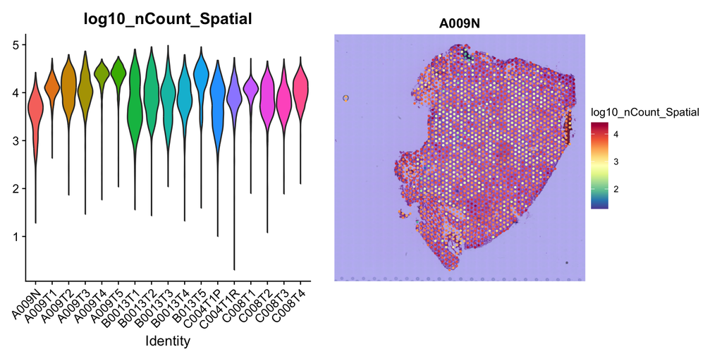

```r
plot1 <- VlnPlot(merged,
                 features = "log10_nCount_Spatial",
                 group.by = "orig.ident",
                 layer = "counts",
                 pt.size = 0) +
  NoLegend()

selected_sample <- "A009N"
plot2 <- SpatialFeaturePlot(merged,
                            features = "log10_nCount_Spatial",
                            images = selected_sample) +
  labs(title = selected_sample) +
  theme(legend.position = "right",
        plot.title = element_text(hjust = 0.5, face="bold"))
wrap_plots(plot1, plot2)
```

**Violin plots:**

- Number of genes
- Mitochondrial content (percent)
- Cell cycle scores

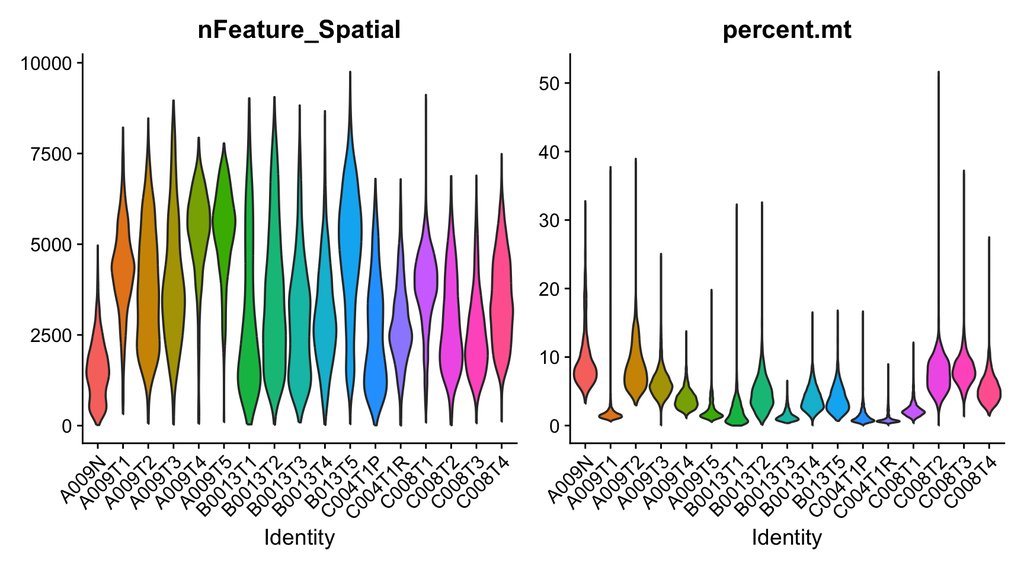

```r
## Number of genes + MT content
VlnPlot(merged,
        features = c("nFeature_Spatial","percent.mt"),
        layer = "counts",
        group.by = "orig.ident",
        pt.size = 0,) +
  NoLegend()
```

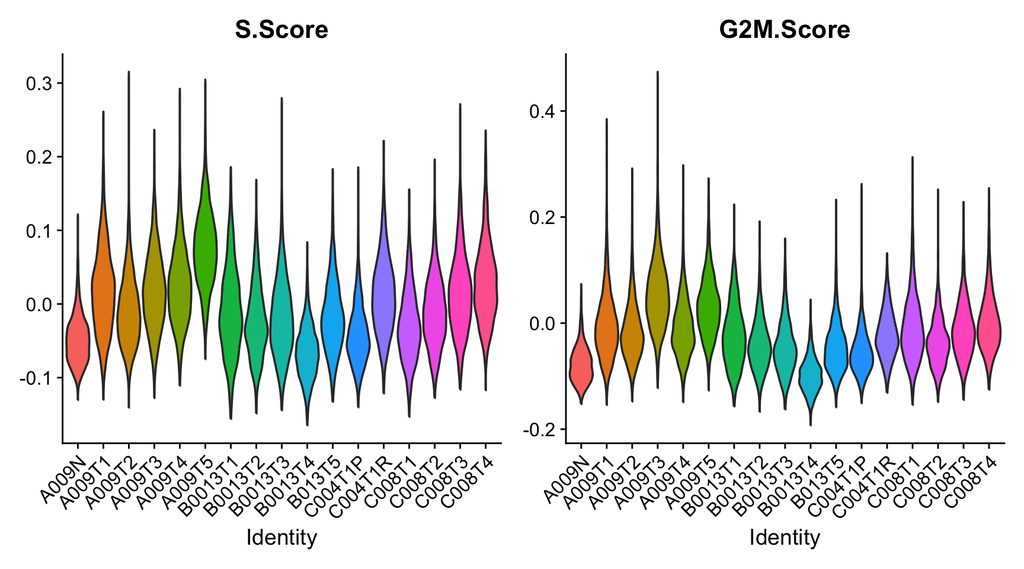

```r
## Cell cycle scores
VlnPlot(merged,
        features = c("S.Score","G2M.Score"),
        layer = "counts",
        group.by = "orig.ident",
        pt.size = 0,) +
  NoLegend()
```

Based on QC plots, we are going to remove all spots with log10(nUMIs) < 3 and MT content > 10%

```r
merged <- subset(merged, log10_nCount_Spatial >= 3 & percent.mt <= 10)
```

Number of spots after QC: 25,096

**Data processing**

Now we can perform the typical processing pipeline for single-cell transcriptomics data (ignoring spatial context)

- SCT normalization and transformation (regress out number of genes and MT content)
- PCA calculation
- Neighbors search in PCA space
- UMAP dimensional reduction
- Unsupervised clustering

```r
# Apply SCTransform on each sample layer
## If getting memory limit error - increase mem.maxVSize()
## usethis::edit_r_environ() to open .Renviron
## R_MAX_VSIZE=50Gb

merged <- SCTransform(merged,
                      layer = "counts",
                      vst.flavor = "v2",
                      assay = "Spatial",
                      vars.to.regress = c("nFeature_Spatial",
                                          "percent.mt"),
                      verbose = FALSE,
                      seed.use = seed_id)
gc()
```

```
##              used    (Mb) gc trigger    (Mb) limit (Mb)   max used    (Mb)
## Ncells   10769739   575.2   17914769   956.8         NA   17914769   956.8
## Vcells 2099686321 16019.4 4907983953 37445.0      51200 4118406925 31421.0
```

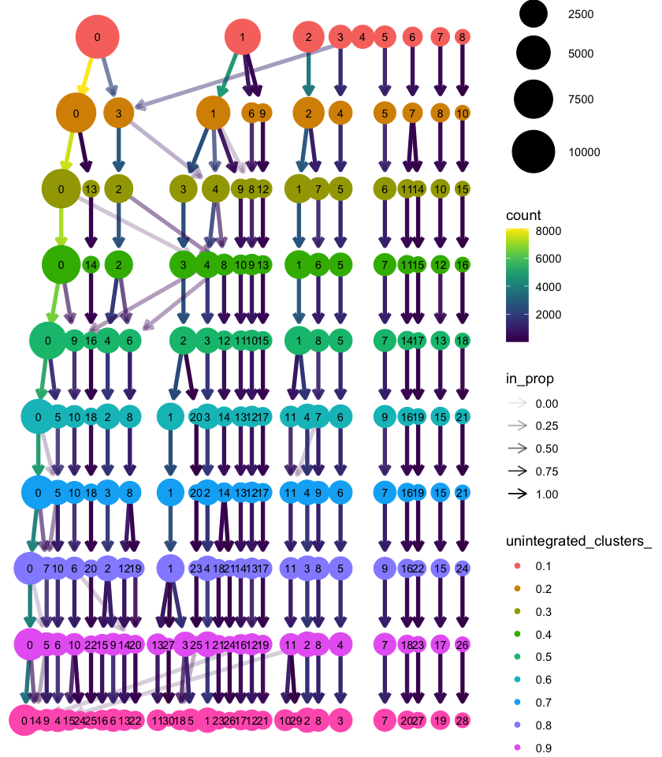

```r
merged <- RunPCA(merged,
                 verbose = FALSE,
                 seed.use = seed_id)

# Unintegrated data processing
merged <- FindNeighbors(merged, dims = 1:30, reduction = "pca", verbose = F) %>%
  RunUMAP(dims = 1:30,
          reduction = "pca",
          reduction.name = "umap.unintegrated",
          verbose = FALSE,
          seed.use = seed_id)

# Run each cluster resolution independently to enable custom names
cluster_resolutions <- seq(0.1, 1.0, 0.1)
for (res in cluster_resolutions) {
  merged <- FindClusters(merged,
                         resolution = res,
                         cluster.name = paste0("unintegrated_clusters_",res),
                         verbose = FALSE,
                         random.seed = seed_id)
}
# Cluster tree plot to identify optimal
clustree(merged, prefix = "unintegrated_clusters_")
```

Based on this cluster tree, we will pick 0.2 cluster resolution as it shows the highest stability

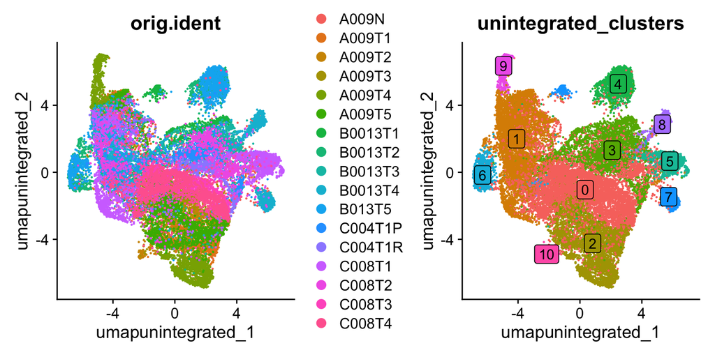

```r
merged$unintegrated_clusters <- merged$unintegrated_clusters_0.2
# UMAP by sample
p1 <- DimPlot(merged, reduction = "umap.unintegrated", group.by = c("orig.ident"), label.size = 2)
# UMAP by unsupervised cluster
p2 <- DimPlot(merged, reduction = "umap.unintegrated", group.by = c("unintegrated_clusters"),
              label = T, label.box = T, label.size = 4) + NoLegend()
wrap_plots(p1, p2, ncol = 2, byrow = F)
```

From those UMAPs, we observe a strong batch effect in the spatial samples. Therefore, we are going to run integrations with the Seurat wrapper for the Harmony package

```r
# Integrated (Harmony) data processing
merged <- IntegrateLayers(object = merged,
                          method = HarmonyIntegration,
                          normalization.method = "SCT",
                          orig.reduction = "pca",
                          new.reduction = "integrated.harmony",
                          verbose = FALSE,
                          seed.use = seed_id)
```

```
## The `features` argument is ignored by `HarmonyIntegration`.
```

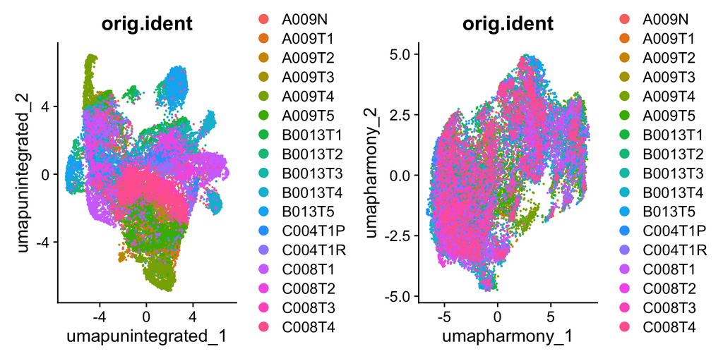

```r
merged <- FindNeighbors(merged,
                        reduction = "integrated.harmony",
                        dims = 1:30,
                        verbose = FALSE) %>%
  RunUMAP(reduction = "integrated.harmony",
          dims = 1:30,
          reduction.name = "umap.harmony",
          verbose = FALSE,
          seed.use = seed_id)

# Comparing sample mixing between unintegrated and integrated with Harmony versions
p1 <- DimPlot(merged, reduction = "umap.unintegrated", group.by = c("orig.ident"), label.size = 2)
p2 <- DimPlot(merged, reduction = "umap.harmony", group.by = c("orig.ident"), label.size = 2)
wrap_plots(p1, p2, ncol = 2, byrow = F)
```

As we can see, Harmony was able to remove technical batch effect and reveal real biological signals

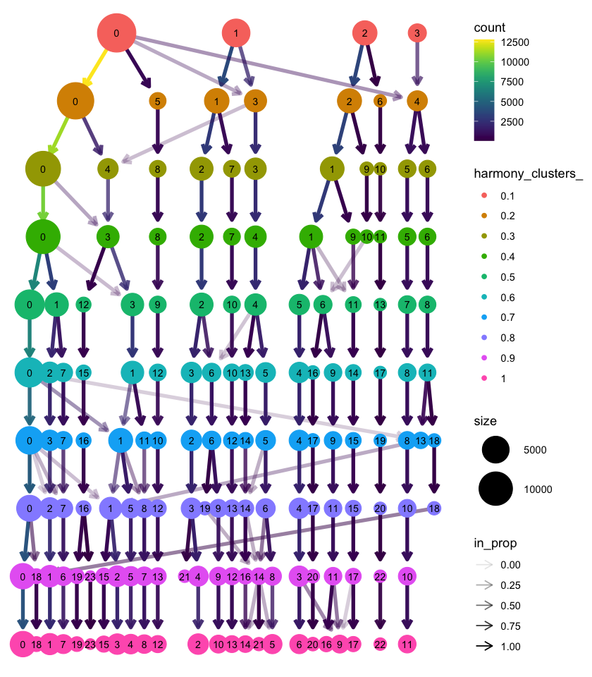

```r
# Find clusters on Harmony embedding
for (res in cluster_resolutions) {
  merged <- FindClusters(merged,
                         resolution = res,
                         cluster.name = paste0("harmony_clusters_",res),
                         verbose = FALSE,
                         random.seed = seed_id)
}
# Cluster tree for harmony integrated clusters
clustree(merged, prefix = "harmony_clusters_")
```

Similarly to unintegrated data, it looks like 0.2 cluster resolution still shows the most stability

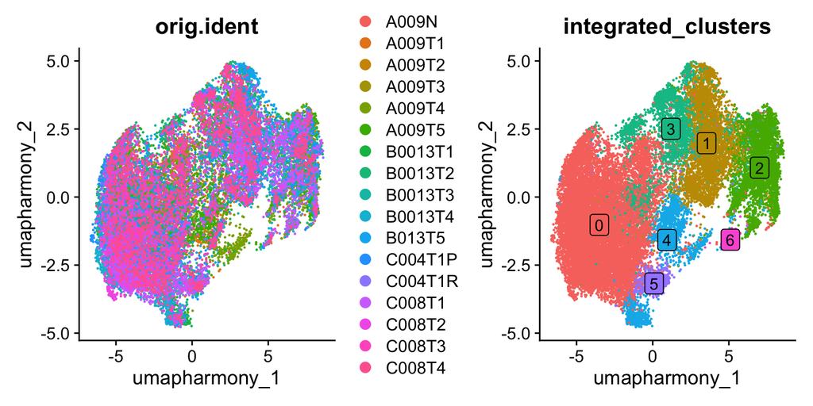

```r
merged$integrated_clusters <- merged$harmony_clusters_0.2
p1 <- DimPlot(merged, reduction = "umap.harmony", group.by = c("orig.ident"), label.size = 2)
p2 <- DimPlot(merged, reduction = "umap.harmony", group.by = c("integrated_clusters"),
        label = T, label.box = T, label.size = 4) + NoLegend()
wrap_plots(p1, p2, ncol = 2, byrow = F)
```

```r
# Save intermediate results
saveRDS(merged, file = here("data", "merged_spatial_processed_harmony.RDS"))
```

Now, after QC and initial data exploratory analysis, we can proceed with spot deconvolution of spatial query data with the RCTD algorithm

## Spot deconvolution with RCTD

Required algorithm inputs

- raw counts from reference data
- cell type annotations for each cell in reference data
- raw counts from query data and spatial spot coordinates on tissue slide

```r
# Prepare reference dataset with cell type annotations (scRNAseq)
# Extract raw counts
counts <- SeuratObject::LayerData(reference_data,
                                  assay = "RNA",
                                  layer = "counts")
# Get factorized vector with cell types annotations
cell_types <- as.factor(reference_data$custom_celltype)
names(cell_types) <- colnames(reference_data)
n_cell_types <- length(levels(cell_types))
# Create RCTD reference
rctd_reference <- Reference(counts,
                            cell_types,
                            reference_data$nCount_RNA)


sample_names <- unique(merged$orig.ident)

# For each sample, run RCTD algorithm and obtain estimated cell type proportions
# Outputs saved to log file
rctd_log <- here("logs","rctd_run.log")
# Run deconvolution in subprocesses
all_proportions <- callr::r(
  func = function(merged,
                  sample_names,
                  rctd_reference) {
    suppressPackageStartupMessages({
      library(spacexr) # 2.2.1
      library(Seurat) # 5.5.0
      library(SeuratObject) # 5.4.0
      library(dplyr) # 1.2.1
      library(tictoc) # 1.2.1
    })
    print(R.home())

    set.seed(123)

    all_proportions <- list()

    for (sample_name in sample_names) {
      tic(paste("Sample", sample_name, "deconvolution"))
      # Filter merged Seurat object
      selected_sample_data <- subset(merged, orig.ident == sample_name)
      # Prepare query dataset (spatial)
      # Extract raw counts
      spatial_counts <- SeuratObject::LayerData(selected_sample_data,
                                                assay = "Spatial",
                                                layer = "counts")
      # Get spot coordinates
      tissue_positions <- GetTissueCoordinates(selected_sample_data,
                                               image = Images(selected_sample_data)[1]) %>%
        select(x,y)
      # Create RCTD spatial data
      rctd_spatial <- SpatialRNA(tissue_positions,
                                 counts = spatial_counts,
                                 nUMI = selected_sample_data$nCount_Spatial)
      # Create RCTD object from reference and spatial data
      # You can specify number of core to enable parallelization
      rctd_obj <- create.RCTD(rctd_spatial, rctd_reference, max_cores = 8)
      # Run RCTD deconvolution in full mode
      # We are assuming that spot can contain any number of reference cell type
      rctd_obj <- run.RCTD(rctd_obj, doublet_mode = "full")
      gc()

      # Get estimated RCTD model weights
      sample_proportions <- rctd_obj@results$weights
      # Normalize weights to obtain proportions (sum to 100%)
      sample_proportions <- sweep(sample_proportions, 1,
                                  rowSums(sample_proportions), `/`) %>%
        as.data.frame()
      # Save sample proportions
      all_proportions[[sample_name]] <- sample_proportions
      toc()
    }
    return(all_proportions)
  },
  args = list(merged = merged,
              sample_names = sample_names,
              rctd_reference = rctd_reference),
  stdout = rctd_log,
  stderr = rctd_log
)

# Merge all proportions into one table and save results
rctd_proportions <- bind_rows(all_proportions)
saveRDS(rctd_proportions, here("results", "rctd_proportions.RDS"))

# Add estimated proportions to merged spatial object metadata and save into new RDS object
# We expect that order of rows did not changed, but we can always double check
# all(rownames(merged@meta.data) == rownames(rctd_proportions))
# TRUE5
merged <- AddMetaData(merged, metadata = rctd_proportions)
saveRDS(merged, file = here("data", "merged_spatial_annotated.RDS"))
```

## Examples of downstream analysis for deconvolution results

Here we will demonstrate few analysis and visualizations that might be useful to understand obtained deconvolution results.

**Plot #1. Estimated proportions per cell types for each spatial spot (by sample)**

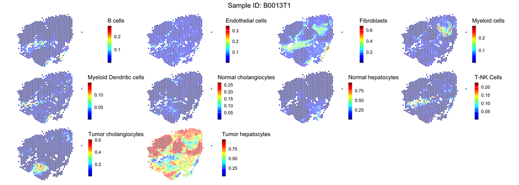

```r
# Load spatial data with deconvolution results (if needed)
# merged <- readRDS(here("data", "merged_spatial_annotated.RDS"))
# Get samples list
sample_names <- unique(merged$orig.ident)

# Store proportions as data.frame
total_columns <- ncol(merged@meta.data)
all_proportions <- merged@meta.data[(total_columns-9):total_columns]
cell_types <- colnames(all_proportions)
all_proportions$sample_name <- merged$orig.ident

# Plot proportions on spatial tissue slides (by sample)
for (selected_sample in sample_names) {

  # Get spot coordinates for selected sample
  tissue_positions <- GetTissueCoordinates(merged,
                                           image = selected_sample) %>%
    select(x,y)
  # Obtain proportions for selected sample
  sample_proportions <- all_proportions %>% filter(sample_name == selected_sample) %>%
    select(all_of(cell_types))

  p <- plot_Proportions_RCTD(tissue_positions,
                              sample_proportions,
                              paste0("Sample ID: ", selected_sample))
  if (selected_sample == "B0013T1") {
    plot1 <- p
  }
  # Save plot
  ggsave(here("results","plots",paste0(selected_sample,"_rctd_proportions.png")),p,
         width = 14, height = 15, dpi = 150, units = "in", device='png')

}

print(plot1)
```

As we expected, the majority of the spots contain tumor hepatocytes. However, we also see a few sites enriched with fibroblasts and immune cells (myeloid and lymphocytes) where the percentage of tumor hepatocytes is reduced. These could represent distinct tumor immune microenvironment niches that could be further investigated for immune activation and tumor-stroma interactions.

**Plot #2. Heatmap with proportions per cell (by sample)**

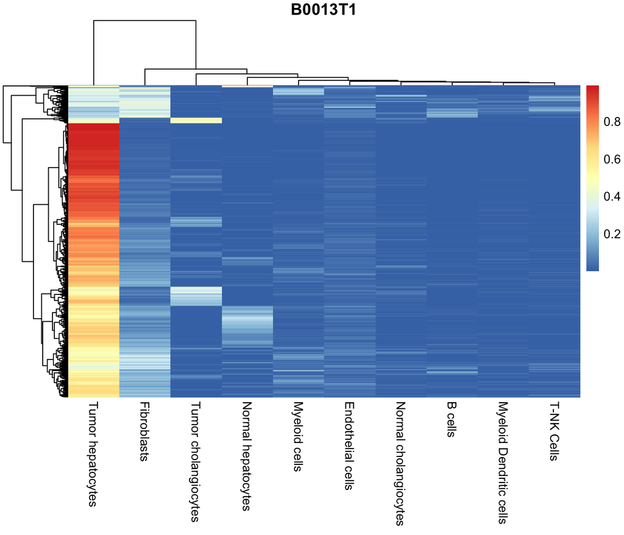

```r
# Get plot for each sample
for (selected_sample in sample_names) {
  # Obtain sample proportion matrix
  sample_proportions <- all_proportions %>%
    filter(sample_name == selected_sample) %>%
    select(all_of(cell_types))
  # Plot spot proportions heatmap
  p <- plot_Heatmap_RCTD(sample_proportions, selected_sample)$gtable
  if (selected_sample == "B0013T1") {
    plot2 <- p
  }
  # Save plot
  ggsave(here("results","plots",paste0(selected_sample,"_rctd_heatmap.png")),p,
         width = 7, height = 6, dpi = 150, units = "in", device='png')
}
grid.newpage()
grid.draw(plot2)
```

**Plot #3. Spatial slides with annotated major cell types per spot**

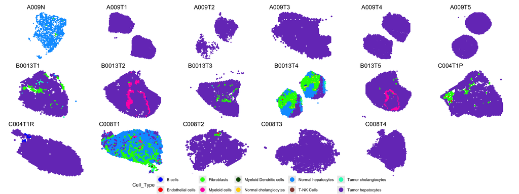

```r
# Assign major cell type for each spot (cell type with highest proportion)
merged@meta.data <- merged@meta.data %>%
  mutate(main_cell_type = names(.[cell_types])[max.col(.[cell_types], ties.method = "first")])

# Prepare plot and save it
p <- plotSpatialDim_by_celltypes(merged,
                            "orig.ident",
                            cell_types, pt.size = 4)
ggsave(here("results","plots","cell_types_spatial.png"),p,
       width = 14, height = 6, dpi = 150, units = "in", device='png')

print(p)
```

As we see, most samples contain predominantly tumor cells, but interestingly, a few samples, such as B0013T4 and C008T1, also show large adjacent normal liver tissue spots. Such areas can be potentially used for further analysis of tumor microenvironments and spatial niches

**Plot #4. Violin plots with FGF19 total expression vs expression by cell type (based on proportions)**

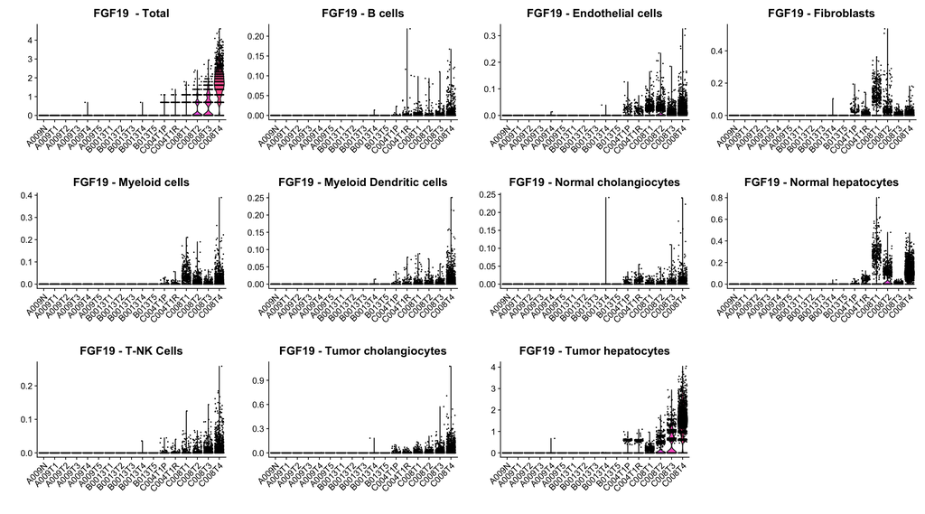

```r
# Naive gene expression imputation based on estimated proportion matrix
# Get normalized (for visualization) expression data
spatial_counts_sct <- as.matrix(LayerData(merged,
                                      assay = "SCT",
                                      layer = "data"))
# Extract proportions for each estimated cell type
# Then multiply GEX matrix by diagonalized proportions to estimate gene expression per cell type
# Finally save estimated matrix to new assay
for (target_cell_type in cell_types) {
  props_vector <- all_proportions[, target_cell_type]
  weight_diag <- Diagonal(x = props_vector)
  pseudo_expr_matrix <- spatial_counts_sct %*% weight_diag
  colnames(pseudo_expr_matrix) <- colnames(spatial_counts_sct)
  rownames(pseudo_expr_matrix) <- rownames(spatial_counts_sct)
  assay_name <- paste0("Pseudo_",
                       str_replace_all(target_cell_type, " ", "_"),
                       "_SCT")
  merged[[assay_name]] <- CreateAssay5Object(data = pseudo_expr_matrix)
}

# Prepare violin plot with total vs cell type expression for selected gene
p <- plotGEX_by_celltypes(merged,
                     "FGF19",
                     "orig.ident",
                     cell_types)
ggsave(here("results","plots","FGF19_GEX_by_celltype.png"),p,
       width = 18, height = 10, dpi = 150, units = "in", device='png')
print(p)
```

This plot shows effects of deconvolution on GEX levels. We selected the FGF19 (Fibroblast Growth Factor 19) gene, which is involved in liver metabolic pathways and is linked to HCC tumor progression and poor therapeutic prognosis. Deconvolution restores correct expression levels for this gene, as only a few spots in the original data show high expression compared to the estimated expression of FGF19 in tumor hepatocytes.

However, for this analysis we used a naive proportional allocation approach for gene expression imputation that doesn’t account for differences in gene expression rates. For proper downstream analysis, we recommend using other methods, for example, CARD (for R) or DestVI (for Python)

**Plot #5. Heatmap illustrating unsupervised clusters enrichment for estimated cell types**

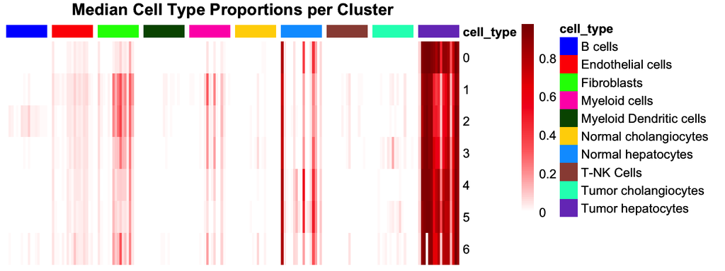

```r
# Collect median proportions per cluster in each sample
median_proportions <- merged@meta.data %>%
  group_by(integrated_clusters, orig.ident) %>%
  summarize(across(all_of(cell_types), median,
                   .names = "{.col}"),
            .groups = "drop")

# Build heatmap of cell type associations with unsupervised cluster
p <- plotClusterHeatmap_by_celltype(median_proportions,
                               cell_types,
                               n_samples = length(unique(merged$orig.ident)))

ggsave(here("results","plots","cluster_celltypes_heatmap.png"),p,
       width = 8, height = 3, dpi = 150, units = "in", device='png')

print(p)
```

As we see, there is no clear association between integrated unsupervised clusters and deconvolution results. Potentially, it could be explained that spots primarily contain tumor hepatocytes, with other cell types present in minimal proportions. Therefore, there is no statistical power to form neighborhoods without tumor cells

# Conclusions

In this tutorial, we showed that deconvolution is a required analytical step when working with data from 10X Visium (standard resolution) or similar spatial technologies (such as Stereo seq v1), which do not guarantee single-cell resolution of detected spatial spots.

Using references from the same biological background (species, tissue, disease) allows for precise estimation of cell-type proportions per spot. We saw that for cancer samples, deconvolution enables detection of tumor niches with a distinct border between tumor, fibroblasts, and normal tissue, which would otherwise be hard to identify.

The RCTD algorithm (with its recent Python implementation, rctd-py) is considered a best practice due to its high accuracy in estimating proportions, including rare cell types, and low resource requirements. However, the R implementation of the RCTD algorithm for deconvolution outside of “doublets” mode is limited. It forced us to implement our custom downstream analysis and visualization functions. Additionally, there is a functional difference between the GitHub and Bioconductor versions of the spacexr package

```r
end_time <- Sys.time()
```

**Execution time**

```r
end_time - start_time
```

```
## Time difference of 1.415171 hours
```

# References

[1] Cable, Dylan M., et al. “Robust decomposition of cell type mixtures in spatial transcriptomics.” Nature Biotechnology 40.4 (2022): 517-526.

[2] Seshachalam, V. P. et al. “Multiomics and multi-region spatial transcriptome analysis reveal cellular networks and pathways associated with HCC recurrence.” JHEP Reports 8, 101790 (2026).

[3] Lu, Y. et al. “A single-cell atlas of the multicellular ecosystem of primary and metastatic hepatocellular carcinoma.” Nature Communications 13, 4594 (2022).

[4] Jiang, S. et al. “Characterization of the distinct immune microenvironments between hepatocellular carcinoma and intrahepatic cholangiocarcinoma.” Cancer Letters 588, 216799 (2024).